# Grammar of Graphics for base plot

Guangchuang Yu

2026-05-21

## Aesthetic mapping

`bb_aes()` for aesthetic mapping, that equivalents to `ggplot2::aes()`.

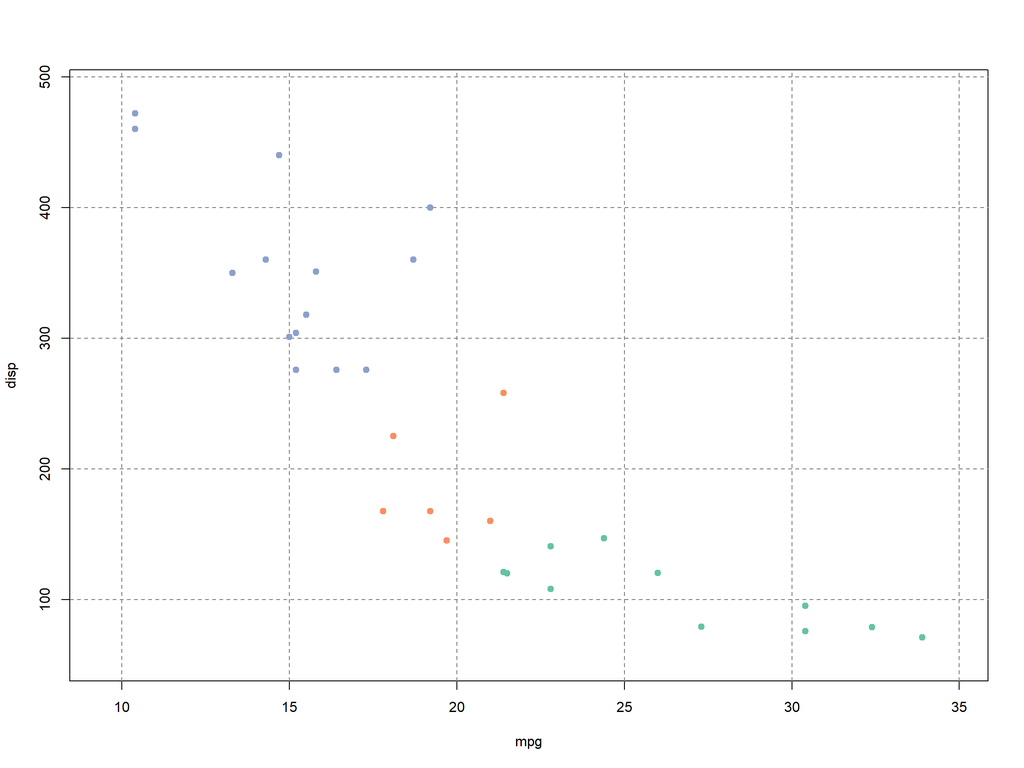

```r
library(plotbb)

p <- bbplot(mtcars, bb_aes(mpg, disp, col = factor(cyl)))
p + bb_grid(col = "grey50", lty = "dashed") + bb_point(pch = 19)
```

## Geometric layer

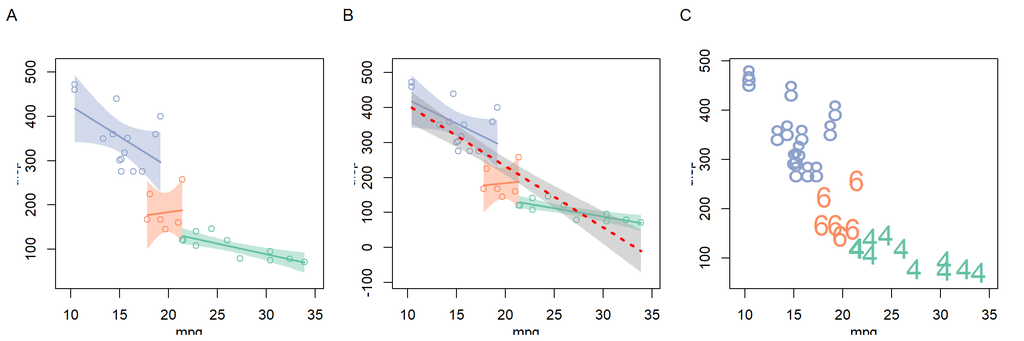

```r
p2 <- p + bb_point() + bb_lm(bb_aes(group = cyl), lwd = 2)
p3 <- p2 + bb_lm(col = "red", lwd = 3, lty = "dotted")
p4 <- p + bb_text(bb_aes(label = cyl), cex = 2)
aplot::plot_list(p2, p3, p4, ncol = 3, tag_levels = "A")
```

### Line, segment and errorbar

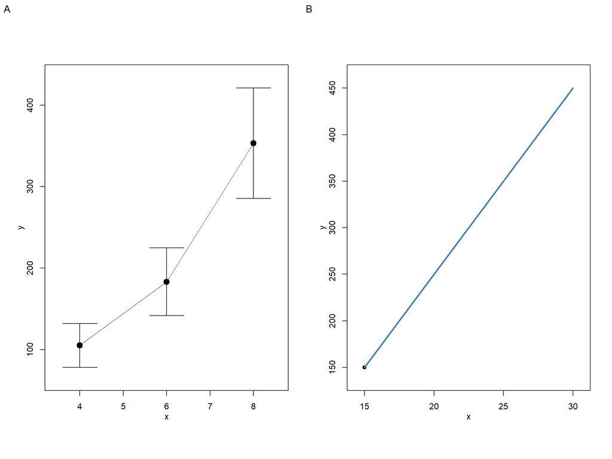

```r
d2 <- group_by(mtcars, cyl) %>%
  summarize(
    x = cyl[1],
    y = mean(disp),
    sd = sd(disp)
  )

g1 <- bbplot(d2, bb_aes(x, y)) +
  bb_line(col = "grey50") +
  bb_point(pch = 19, cex = 1.5) +
  bb_errorbar(bb_aes(ymin = y - sd, ymax = y + sd), width = 0.8)

seg <- data.frame(x = 15, y = 150, xend = 30, yend = 450)
g2 <- bbplot(seg, bb_aes(x, y)) +
  bb_point(pch = 19) +
  bb_segment(bb_aes(xend = xend, yend = yend), lwd = 3, col = "steelblue")

aplot::plot_list(g1, g2, ncol = 2, tag_levels = "A")
```

### Bar plot

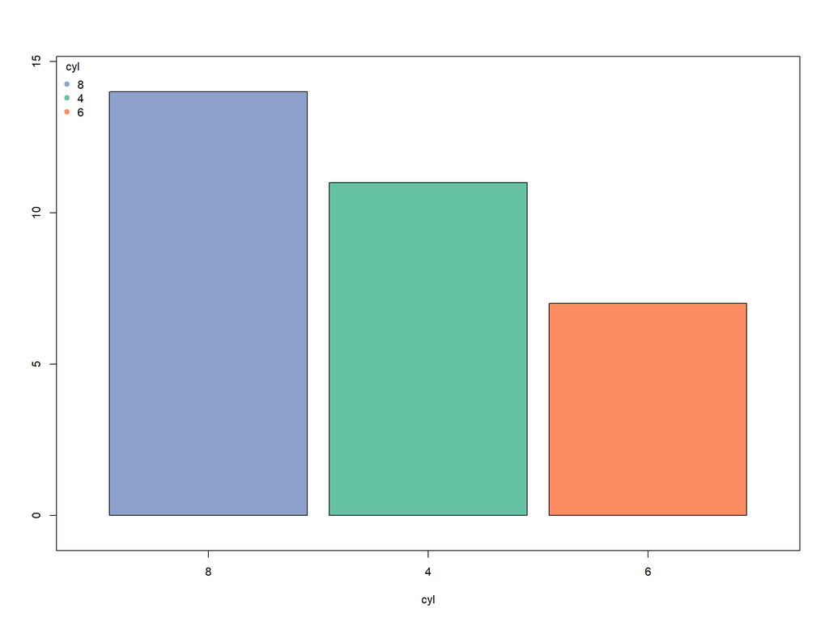

```r
mtcars$cyl <- factor(mtcars$cyl, levels = c(8, 4, 6))
bbplot(mtcars, bb_aes(cyl, col = cyl)) +
  bb_bar(stat = "count") +
  bb_legend(position = "topleft")
```

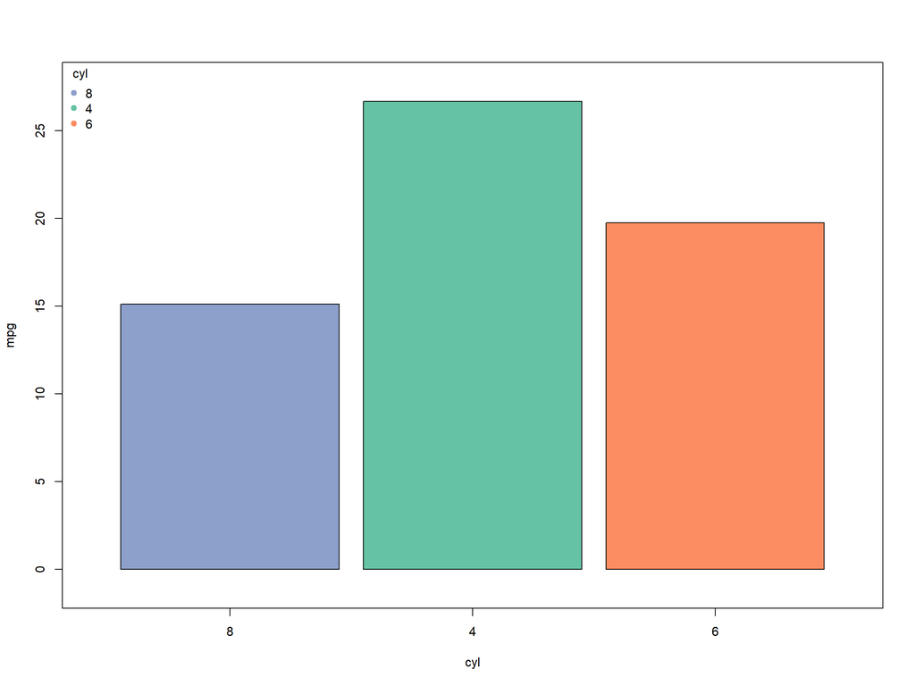

```r
dbar <- group_by(mtcars, cyl) %>%
  summarize(mpg = mean(mpg), .groups = "drop")
bbplot(dbar, bb_aes(cyl, mpg, col = cyl)) +
  bb_bar() +
  bb_legend(position = "topleft")
```

### Boxplot and histogram

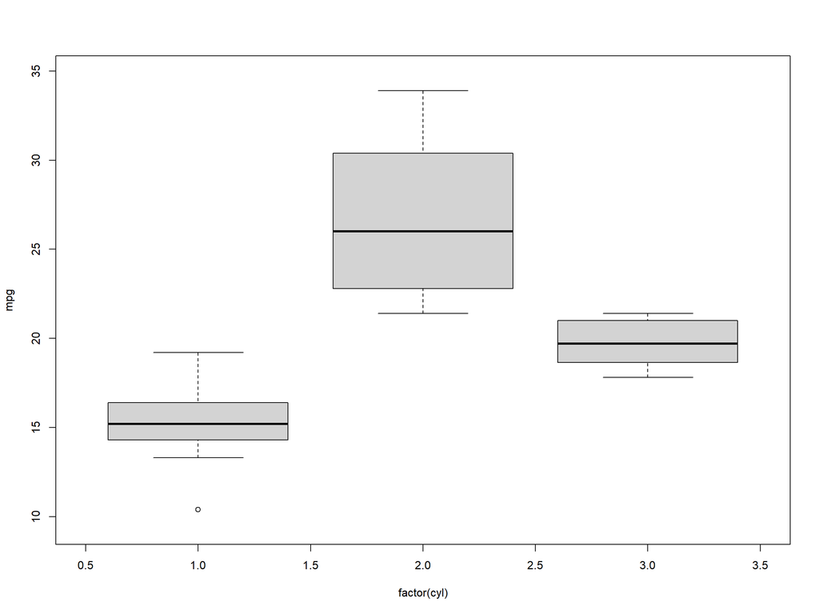

```r
bbplot(mtcars, bb_aes(factor(cyl), mpg)) +
  bb_boxplot(fill = "grey90")
```

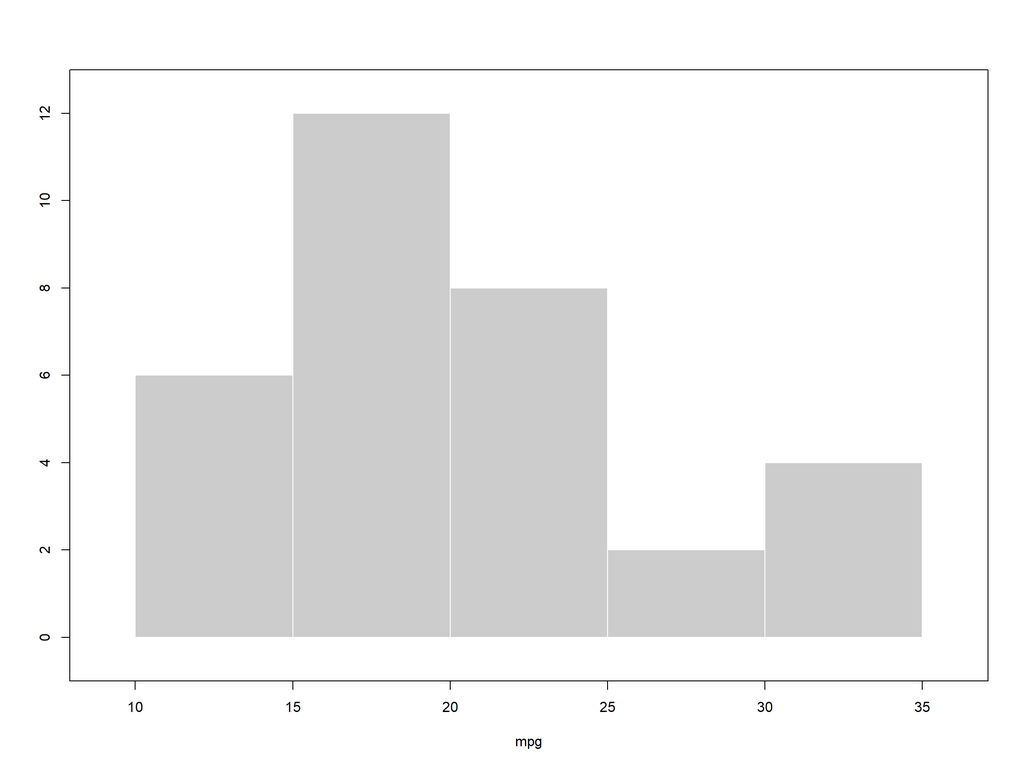

```r
bbplot(mtcars, bb_aes(mpg)) +
  bb_hist(col = "grey80", border = "white")
```

### Significance annotations

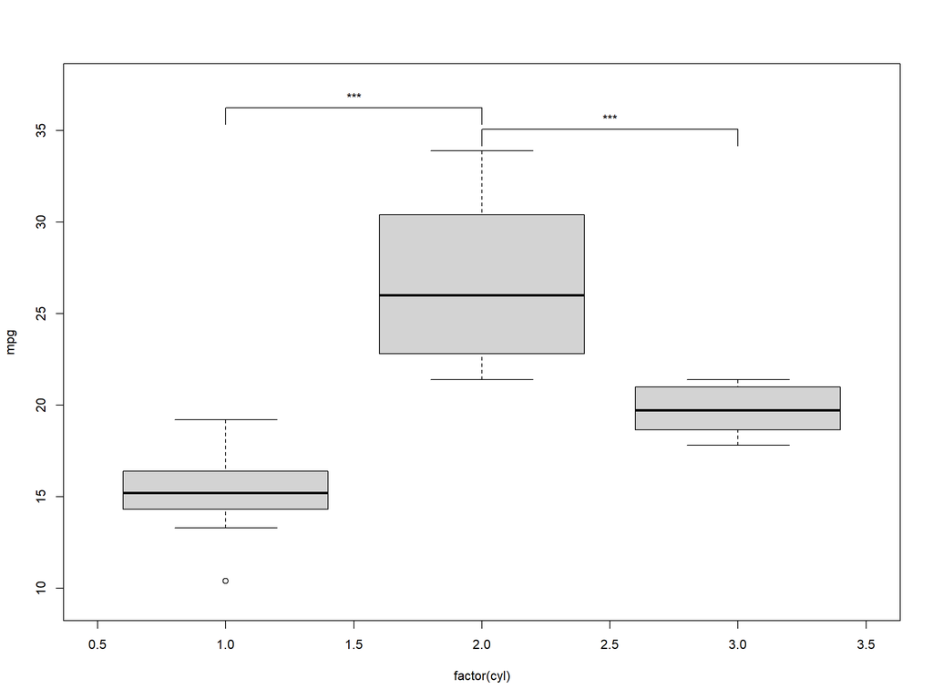

```r
bbplot(mtcars, bb_aes(factor(cyl), mpg)) +
  bb_boxplot(fill = "grey90") +
  bb_signif(comparisons = list(c("4", "6"), c("4", "8")))
```

### Heatmap

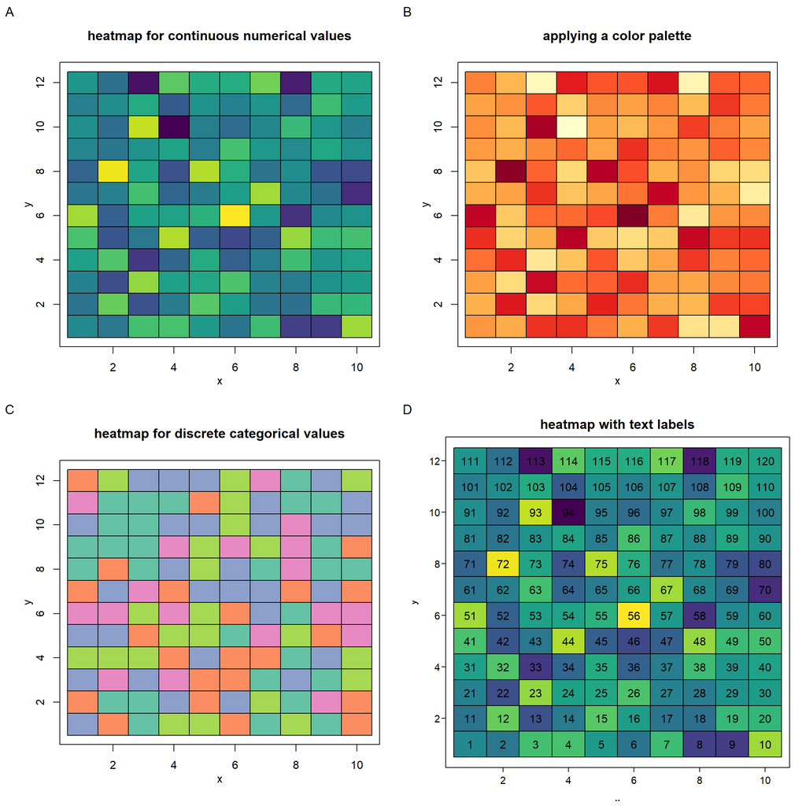

```r
df <- data.frame(
  x = rep(1:10, 12),
  y = rep(1:12, each = 10),
  values = rnorm(120, mean = 10, sd = 5),
  type = sample(LETTERS[1:5], 120, replace = TRUE),
  stringsAsFactors = FALSE
)

h1 <- bbplot(df, bb_aes(x, y, col = values)) + bb_tile() +
  bb_title("heatmap for continuous numerical values")
h2 <- bbplot(df, bb_aes(x, y, col = values)) + bb_tile() + bb_scale_col_palette("YlOrRd") +
  bb_title("applying a color palette")
h3 <- bbplot(df, bb_aes(x, y, col = type)) + bb_tile() +
  bb_title("heatmap for discrete categorical values")
h4 <- bbplot(df, bb_aes(x, y, col = values)) + bb_tile() + bb_text(col = "black") +
  bb_title("heatmap with text labels") + bb_theme_expand()
aplot::plot_list(h1, h2, h3, h4, ncol = 2, tag_levels = "A")
```

### Supported layers

- bb_grid
- bb_point
- bb_lm
- bb_text
- bb_tile
- bb_line
- bb_segment
- bb_errorbar
- bb_bar
- bb_boxplot
- bb_hist
- bb_facet_wrap
- bb_signif

## Setting labels

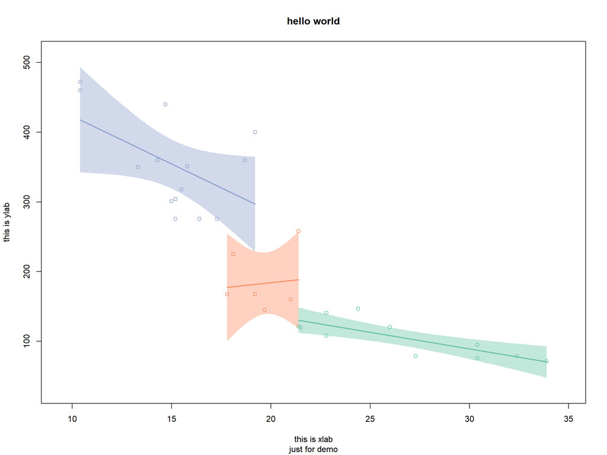

```r
p2 + bb_labs(
  title = "hello",
  sub = "just for demo",
  xlab = "this is xlab",
  ylab = "this is ylab"
) +
  bb_title("hello world")
```

## Theme

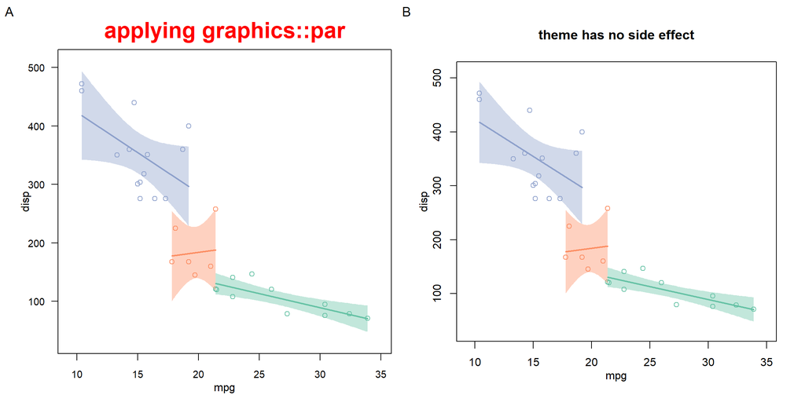

```r
g <- p2 +
  bb_theme(
    col.main = "red",
    cex.main = 2,
    mar = c(4, 4, 3, 1)
  ) +
  bb_title("applying graphics::par")
g2 <- p2 + bb_title("theme has no side effect")
aplot::plot_list(g, g2, ncol = 2, tag_levels = "A")
```

`bb_theme` has no side effect and will only apply to the `bbplot` object that it added to. This is very important for developing pre-defined themes.

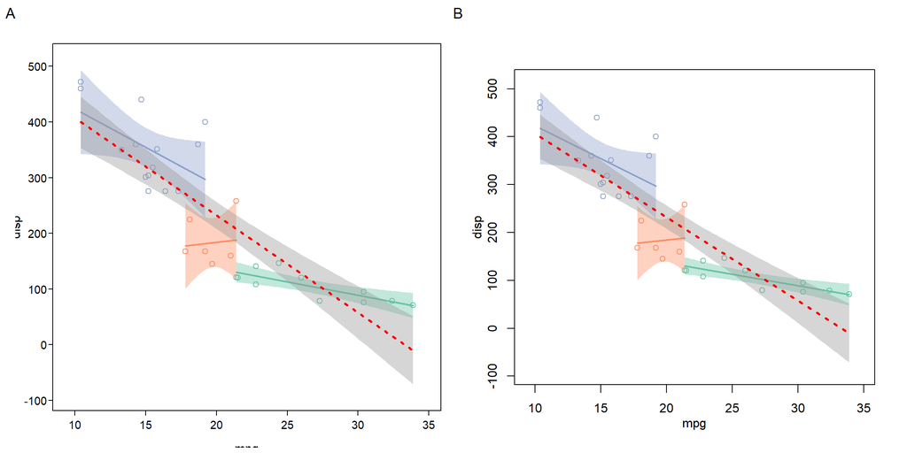

```r
p4 <- p3 + bb_theme_expand()
aplot::plot_list(p4, p3, ncol = 2, tag_levels = "A")
```

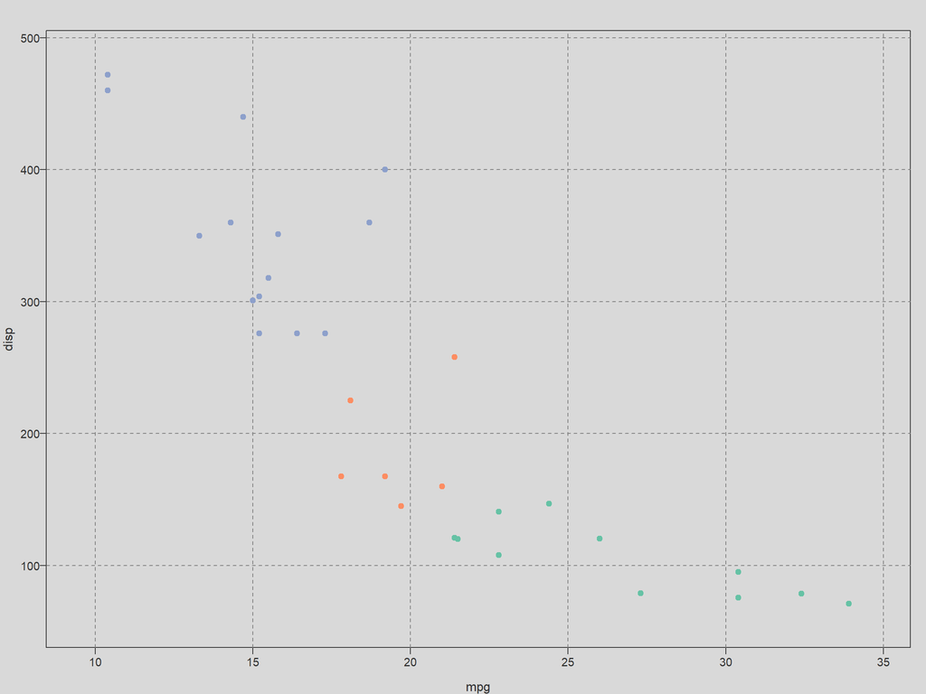

```r
p + bb_grid(col = "grey50", lty = "dashed") +
  bb_point(pch = 19) +
  bb_theme_expand() +
  bb_theme_grey()
```

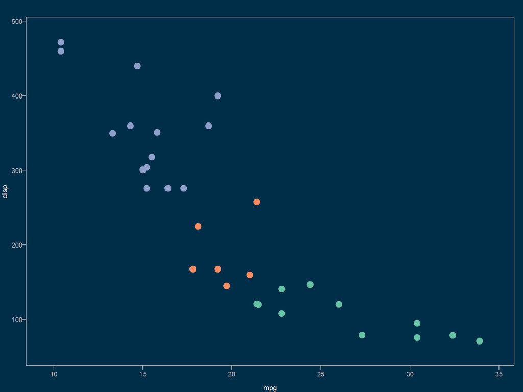

```r
p + bb_point(pch = 19, cex = 2) +
  bb_theme_expand() +
  bb_theme_deepblue()
```

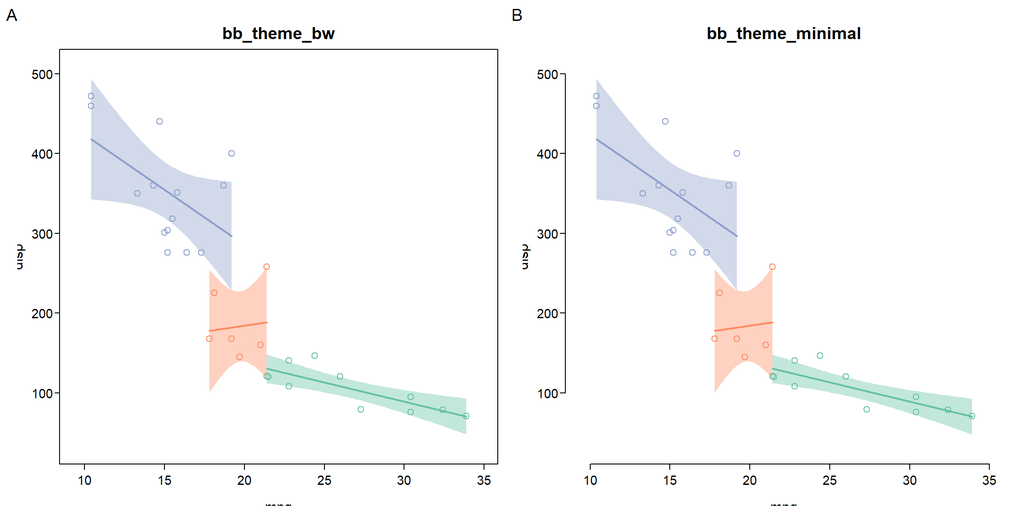

```r
g_bw <- p2 + bb_theme_expand() + bb_theme_bw() + bb_title("bb_theme_bw")
g_min <- p2 + bb_theme_expand() + bb_theme_minimal() + bb_title("bb_theme_minimal")
aplot::plot_list(g_bw, g_min, ncol = 2, tag_levels = "A")
```

### Supported themes

- `bb_theme_expand`
- `bb_theme_grey`
- `bb_theme_deepblue`
- `bb_theme_bw`
- `bb_theme_minimal`

## Scale

### Supported scales

- `bb_scale_col_palette`
- `bb_scale_col_manual`
- `bb_scale_col_gradient`
- `bb_scale_pch_manual`
- `bb_scale_lty_manual`
- `bb_scale_cex_manual`
- `bb_scale_cex_continuous`

Color scales can be added anywhere in the `+` chain and will affect both layers and legends.

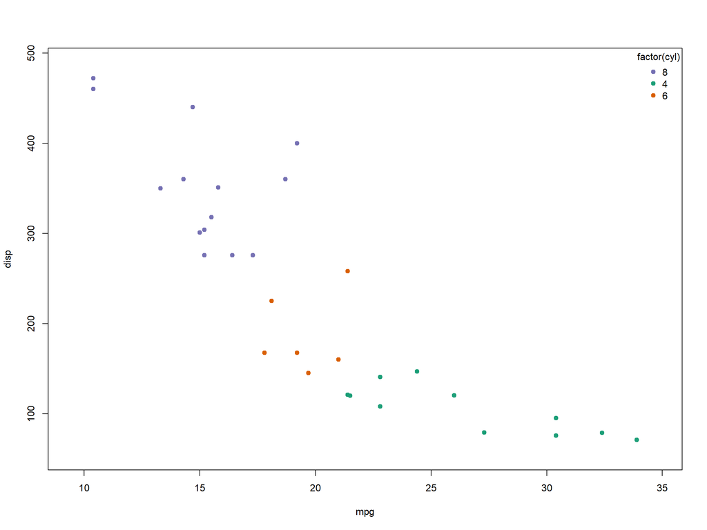

```r
pal <- c(`4` = "#1b9e77", `6` = "#d95f02", `8` = "#7570b3")
bbplot(mtcars, bb_aes(mpg, disp, col = factor(cyl))) +
  bb_point(pch = 19) +
  bb_scale_col_manual(pal) +
  bb_legend()
```

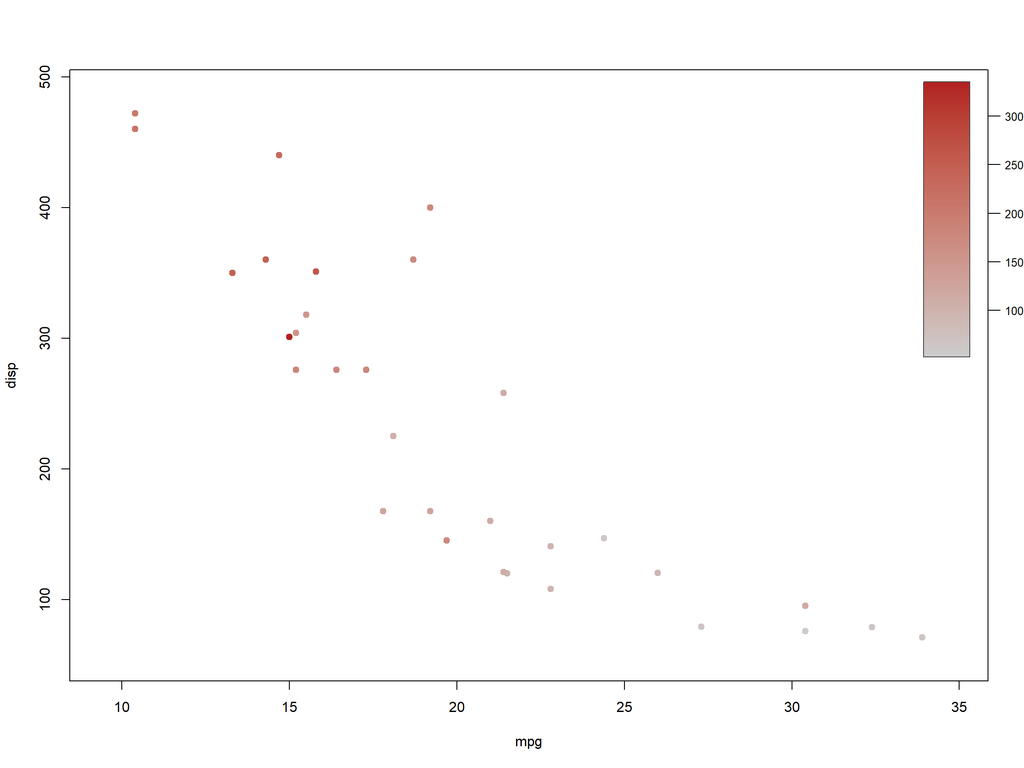

```r
bbplot(mtcars, bb_aes(mpg, disp, col = hp)) +
  bb_point(pch = 19) +
  bb_scale_col_gradient(low = "grey80", high = "firebrick") +
  bb_legend()
```

### Scales for pch, lty and cex

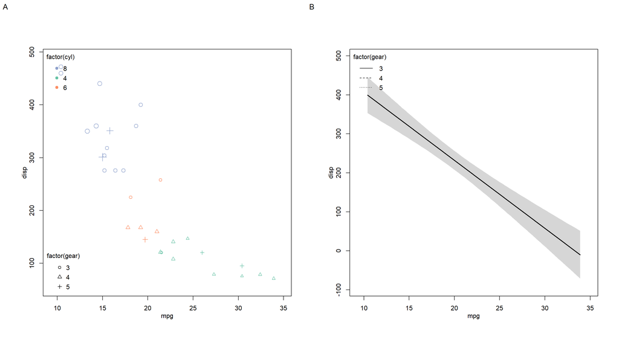

```r
p5 <- bbplot(mtcars, bb_aes(mpg, disp, col = factor(cyl), pch = factor(gear), cex = hp)) +
  bb_point() +
  bb_scale_cex_continuous(range = c(0.8, 2)) +
  bb_legend(aesthetic = "col", position = "topleft") +
  bb_legend(aesthetic = "pch", position = "bottomleft")

p6 <- bbplot(mtcars, bb_aes(mpg, disp, lty = factor(gear))) +
  bb_lm(lwd = 2) +
  bb_scale_lty_manual(values = c(`3` = "solid", `4` = "dashed", `5` = "dotted")) +
  bb_legend(aesthetic = "lty", position = "topleft")

aplot::plot_list(p5, p6, ncol = 2, tag_levels = "A")
```

## Legend

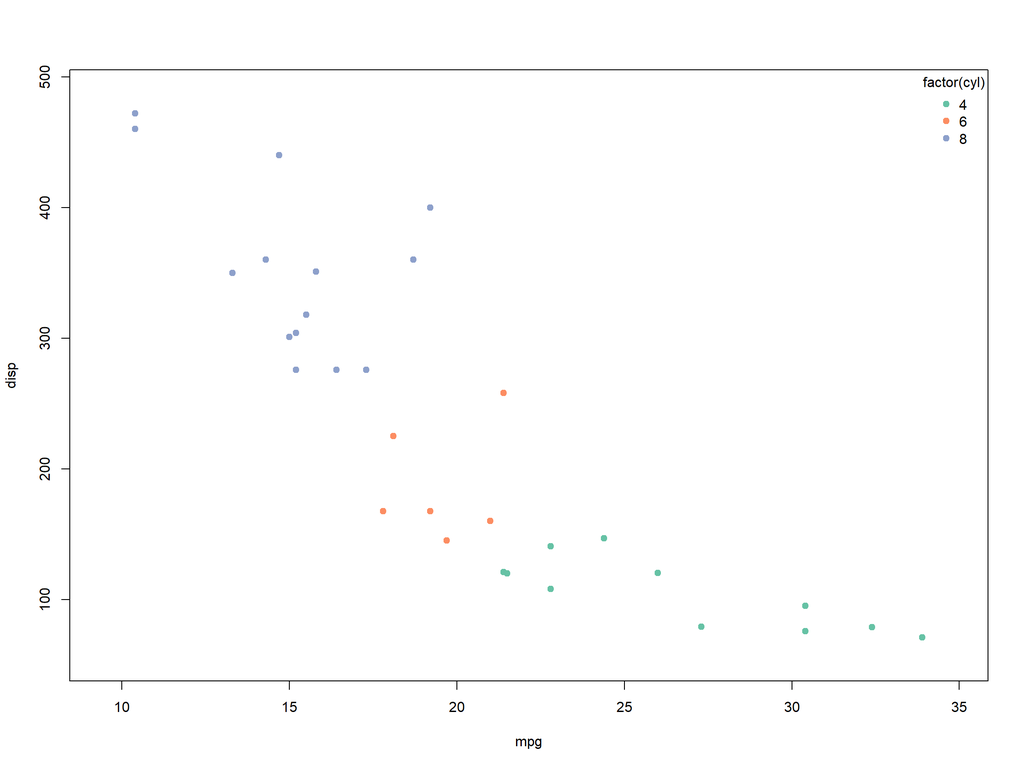

```r
p + bb_point(pch = 19) + bb_legend()
```

## Facet

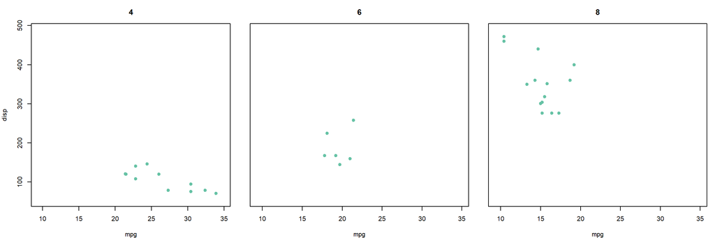

```r
p + bb_point(pch = 19) + bb_facet_wrap(~cyl, ncol = 3)
```

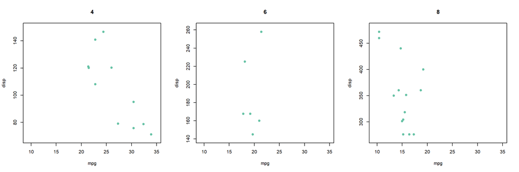

```r
p + bb_point(pch = 19) + bb_facet_wrap(~cyl, ncol = 3, scales = "free_y")
```

## Using existing code with plotbb

Suppose we have existing code to plot something:

```r
plot(mtcars$mpg, mtcars$disp)
abline(lm(disp ~ mpg, data = mtcars), col = "red")
```

We can wrap the codes into a function:

```r
f <- function() {
  plot(mtcars$mpg, mtcars$disp)
  abline(lm(disp ~ mpg, data = mtcars), col = "red")
}
```

Then we can convert it to a `bbplot` object. The plot produced by the function will be used as the canvas, and we can apply theme and add layers to it:

```r
library(dplyr)
d <- group_by(mtcars, cyl) %>%
  summarize(xm = mean(mpg), ym = mean(disp))

pp <- as.bbplot(f) +
  bb_theme_expand() +
  bb_theme_grey() +
  bb_lm(bb_aes(mpg, disp, group = cyl, col = factor(cyl)), data = mtcars, lwd = 2, lty = "dashed") +
  bb_point(bb_aes(xm, ym, col = factor(cyl)), data = d, pch = 19, cex = 2) +
  bb_title("hello plotbb") +
  bb_grid(col = "grey30", lty = "dashed")
```

As there are many features currently not available, `plotbb` supports adding layers using base graphics commands that you are already familiar with. Any base graphics commands in formula, expression or function can be served as layer to be added to a `bbplot` object.

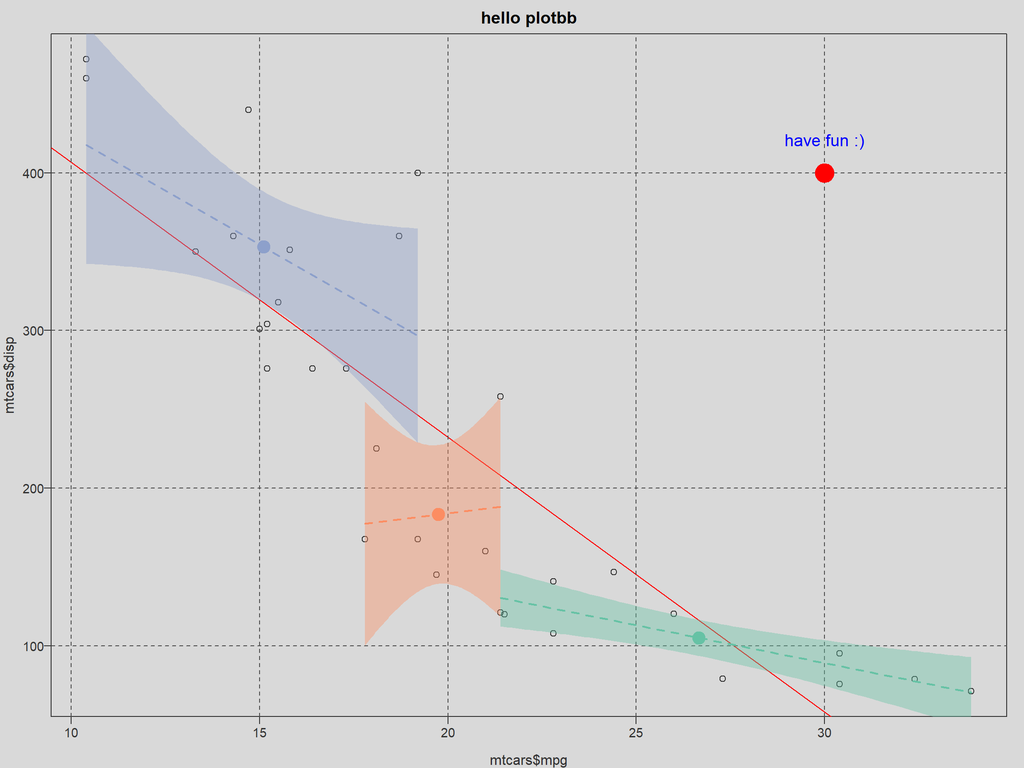

```r
pp + (~points(30, 400, pch = 19, col = "red", cex = 3)) +
  ~text(30, 420, label = "have fun :)", col = "blue", cex = 1.2)
```

Here is another example to use `plotbb` with the `ape` package to visualize phylogenetic tree.

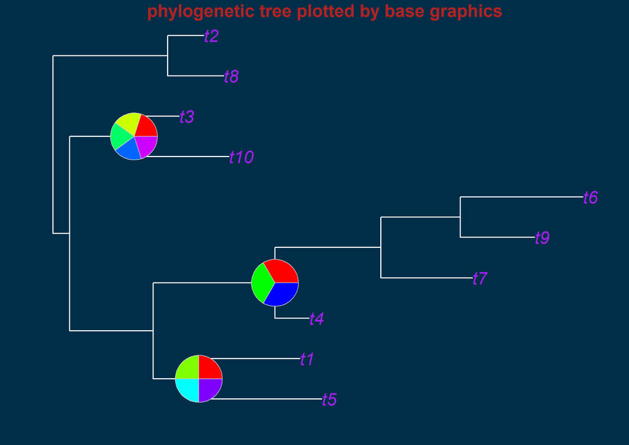

```r
require(ape)
set.seed(2020 - 09 - 10)
x = rtree(10)

p = as.bbplot(
  function()
    plot(
      x,
      cex = 2,
      edge.width = 2,
      edge.color = "white",
      tip.color = "purple"
    )
)

p + bb_theme_expand() + bb_theme_deepblue() +
  (~nodelabels(node = 14, pie = matrix(rep(1, 4), 1), cex = 2)) +
  (~nodelabels(node = 15, pie = matrix(rep(1, 3), 1), cex = 2)) +
  (~nodelabels(node = 18, pie = matrix(rep(1, 5), 1), cex = 2)) +
  bb_labs(title = "phylogenetic tree plotted by base graphics") +
  bb_theme(col.main = "firebrick", cex.main = 2)
```